# Anàlisi discriminant lineal

L’anàlisi discriminant lineal, o LDA, és un mètode de classificació dins de l’aprenentatge supervisat que permet classificar una variable categòrica entre els seus diferents nivells. Per classificar entre diferents classes s’estimen una o diverses funcions discriminants, que representen hiperplans i separen l’espai d’observacions en diferents regions.

Com que el LDA està basat en mètodes factorials, es prenen només les columnes numèriques com a variables predictives.

La variable que es vol classificar és la variable Target, la qual té 4 modalitats: Dropout, Enrolled, Graduate i Unknown. S’eliminen les observacions de la modalitat Unknown, ja que en realitat són *missing values* i no té sentit que formin una categoria específica en la qual classificar observacions.

Com que hi ha 3 modalitats per a la variable Target, es busquen dues funcions discriminants per garantir que es pugui arribar a discriminar i separar entre les tres classes. La següent taula mostra els coeficients de les funcions discriminants:

|  | LD1 | LD2 |
| --- | --- | --- |
| age | -0.0437742 | 0.0435533 |
| grades_sem_1 | 0.0242356 | 0.1867579 |
| no_eval_sem_1 | -0.0342150 | -0.2431166 |
| grades_sem_2 | 0.2044008 | -0.1323255 |
| no_eval_sem_2 | -0.0699950 | -0.4638810 |
| unemployment_rate | 0.0098169 | 0.2392478 |
| inflation_rate | -0.0166414 | -0.0111436 |
| gdp | 0.0054842 | 0.0252665 |

Com que s’han calculat dues funcions discriminants, apareixen dues columnes noves que s’afegeixen a la base de dades que conté les columnes numèriques de la base original.

```
## [1] "variable LD1 Vw = 0.999999999999999 Vb = 1139.70636146981 separation = 1139.70636146981"
## [1] "variable LD2 Vw = 0.999999999999995 Vb = 10.6790279023928 separation = 10.6790279023929"
```

Es dibuixen en un histograma els coeficients de cada funció discriminant.

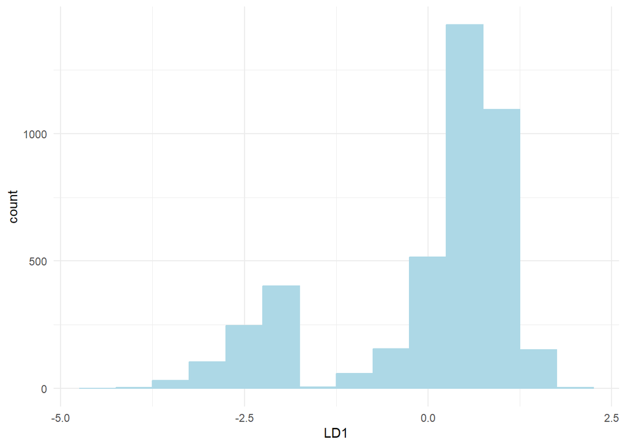

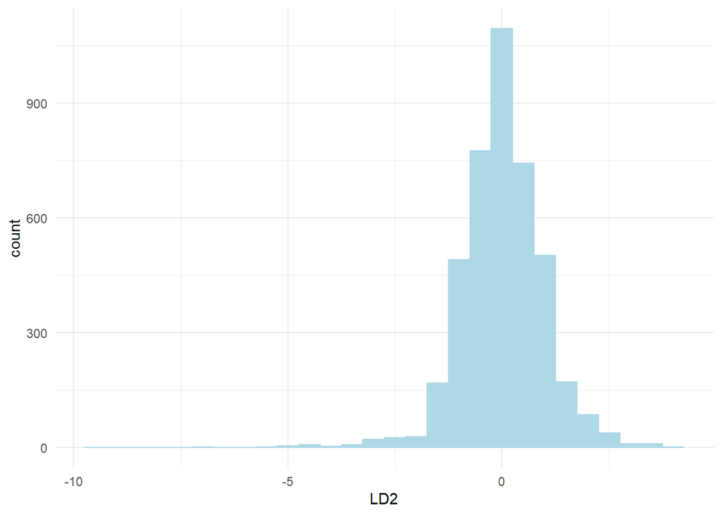

Es poden també representar en histogrames els coeficients de la funció discriminant segons el nivell de la variable Target.

LD1

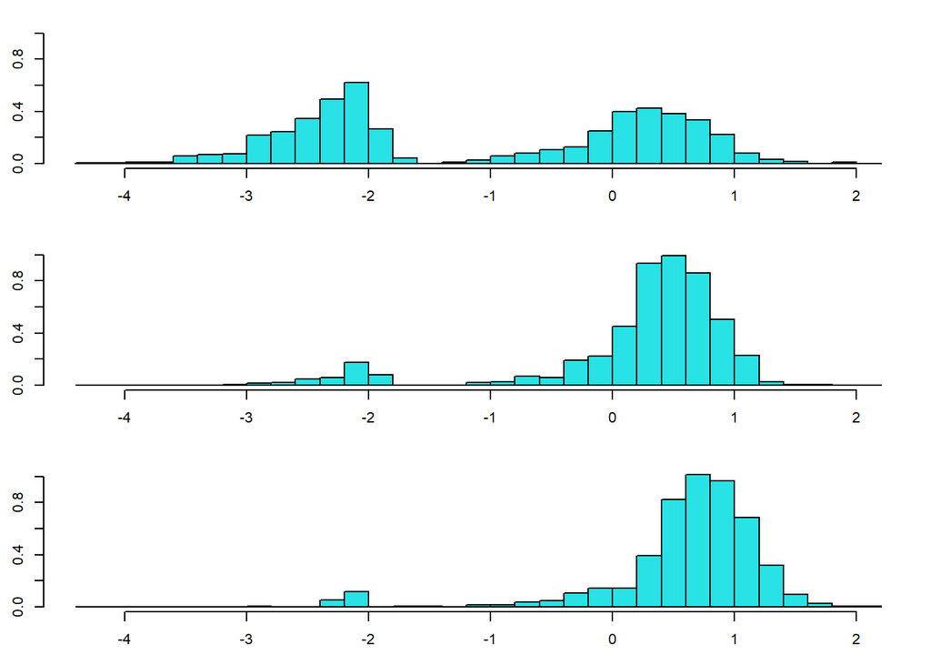

LD2

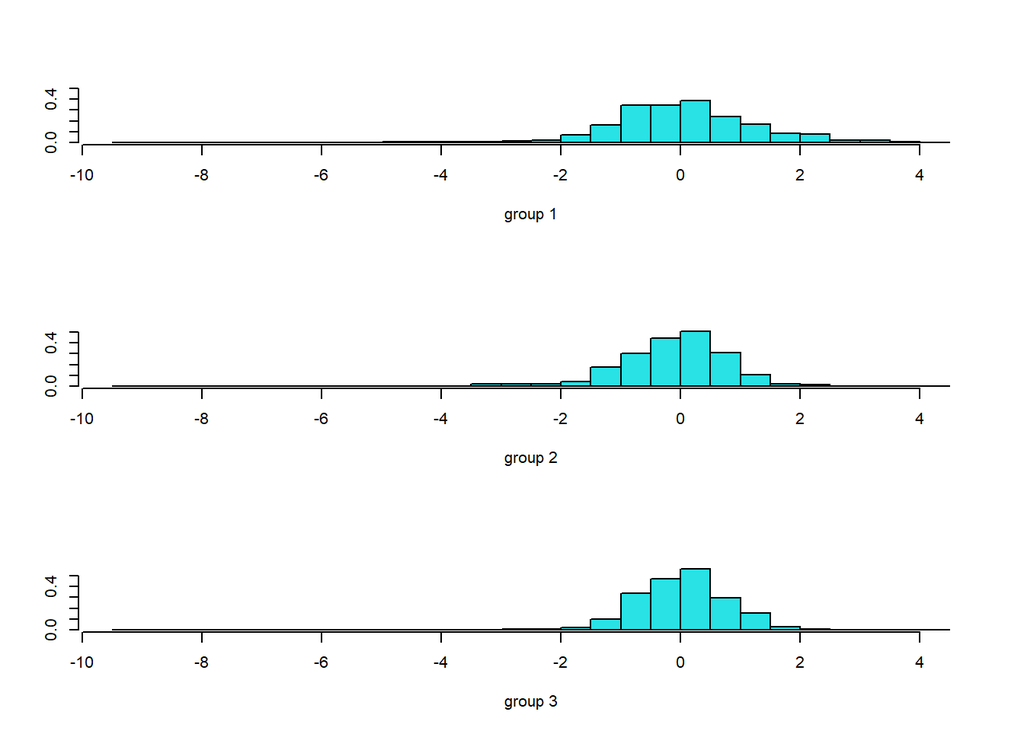

Es poden també representar les diferents classes de la següent manera:

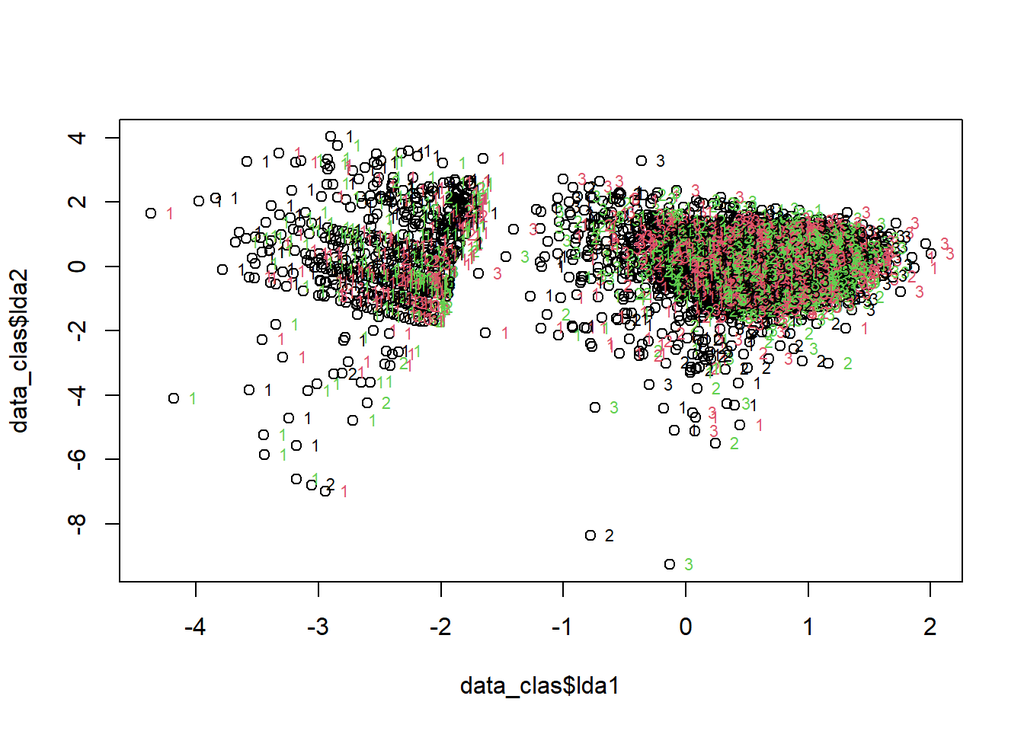

```
##               age      grades_sem_1     no_eval_sem_1      grades_sem_2
##        0.04355331        0.18675786       -0.24311662       -0.13232545
##     no_eval_sem_2 unemployment_rate    inflation_rate               gdp
##       -0.46388104        0.23924779       -0.01114359        0.02526652
```

```
##               age      grades_sem_1     no_eval_sem_1      grades_sem_2
##      -0.043774186       0.024235650      -0.034215037       0.204400831
##     no_eval_sem_2 unemployment_rate    inflation_rate               gdp
##      -0.069995008       0.009816912      -0.016641377       0.005484226
```

En tots els gràfics s’aprecia el mateix, no es discriminen bé les modalitats.

Un cop s’han predit les classes de la variable Target, es pot calcular la matriu de confusió per avaluar la precisió de les funcions discriminants que s’han calculat a l’hora de separar les classes.

```
##
##    1    2    3
## 1353  750 2104
```

S’observa, però, que la precisió del model és força baixa, al voltant del 15%.

```
## [1] 0.1568814
```

Amb la precisió calculada, es pot obtenir l’error de classificació:

```
## [1] 0.8431186
```